[figure not shown]

# Tillsammans för ett hållbart Dalarna

Dalarna står tillsammans med övriga Sverige, Europa och världen inför stora samhällsutmaningar. För att skapa en hållbar framtid för Dalarna antog Regionfullmäktige i juni 2021 en ny regional utvecklingsstrategi, “Dalastrategin - Tillsammans för ett hållbart Dalarna”.

Strategin är ett stöd och en språngbräda i arbetet med att rusta Dalarna för att möta framtidsutmaningarna och göra dem till möjligheter. Dalastrategin är indelad i tre målområden som kopplar an till de olika dimensionerna av hållbarhet - miljömässig, ekonomisk och social hållbarhet:

- ett klimatsmart Dalarna
- ett sammanhållet Dalarna
- ett konkurrenskraftigt Dalarna

I Dalastrategin belyses att en miljömässigt hållbar omställning är en utmaning som berör alla delar av samhället, från global till lokal nivå och inom alla sektorer.

En princip för genomförandet av Dalastrategin är ett kunskapsbaserat arbetssätt. Det innebär bland annat att arbeta aktivt med uppföljning, utvärdering och att skapa ett kontinuerligt lärande. En central del av uppföljningsarbetet är de indikatorer som kopplas till respektive målområde, och den här rapporten är en del av den årliga uppföljningen som beskriver utvecklingen i Dalarna på vägen till en hållbar framtid.

| Klimatsmart | Konkurrenskraftigt | Sammanhållet |
| --- | --- | --- |
| Utsläpp av klimatpåverkande växthusgaser | Representation i chefspositioner | Trångboddhet |
| Energiproduktion | Ginikoefficient | Boendetyper |
| Energieffektivitet | Internationaliseringsgrad | Tillgång till service och tjänster |
| Insamlat hushållsavfall (kg/person) | Branschbredd och branschstruktur* | Tillgänglighet till vård* |
| Avfall/BRP | Nyföretagande | Deltagande i det civila samhället |
| Laddinfrastruktur för fordon* | Andel av transporter via olika trafikslag* | Andel av hushåll som har tillgång till bredband |
| Andel kollektivt resande | Tillgänglighet (restid) till arbetsplatser/skolor* | Valdeltagande |
| Självförsörjningsgrad av energi och livsmedel | Infrastrukturinvesteringar* | Tillit till andra människor |
| Andel hektar formellt skyddad produktiv skogsmark | Matchningsgrad | Digitalt deltagande* |
| Arealen betesmark och areal med särskilt höga biologiska värden* | Andel sysselsatta | Andel invånare i ekonomiskt utsatta hushåll |
|  | Långtidsarbetslöshet | Andel unga som upplever att de är delaktiga i sin kommun |
|  | Andel unga som inom fyra år fullföljer gymnasieutbildning | Självskattad hälsa |
|  | Andel högskoleutbildade i befolkningen |  |
|  | Etableringstid för nyanlända |  |
|  | Investeringar i FoU |  |

*Indikatorn är under utveckling och datainsamling pågår.

# Ett klimatsmart Dalarna

Ett klimatsmart Dalarna är ett resurseffektivt Dalarna utan klimatpåverkande utsläpp. Resande sker på ett enkelt och miljömässigt hållbart sätt. I ett klimatsmart Dalarna är samhällets robusthet och resiliens vid klimatförändringar god.

Den miljömässiga dimensionen i regional utveckling handlar bland annat om att säkerställa att ekosystemen fortsätter att leverera de tjänster som människor och samhällen är beroende av. Genom att gå före i en miljömässigt hållbar omställning gynnas innovationer och regionalt företagande, med målsättningen att regionala lösningar bidrar till att lösa globala problem. Det är också vägen fram till goda livsmiljöer och levnadsvillkor.

## Utsläpp av klimatpåverkande växthusgaser

År 2017 antog Sverige ett långsiktigt nationellt mål om att landet ska vara klimatneutralt år 2045. Detta innebär en minskning av växthusgasutsläpp med minst 85 procent inom landets gränser i jämförelse med utsläppen år 1990. Målet innebär i princip att alla sektorer och verksamheter behöver vara fossilfria år 2045. Sveriges nationella mål är i linje med det europeiska målet om ett klimatneutralt EU till år 2050 och det internationella Parisavtalet som innebär att jordens länder strävar efter att ökningen av den globala genomsnittstemperaturen inte blir mer än 1,5°C till år 2050 i förhållande till den förindustriella nivån, samt att den i vilket fall inte överstiger 2°C.

De klimatpåverkande växthusgaserna innefattar fler ämnen än koldioxid. Ett exempel är metangas, som därtill är betydligt skadligare per enhet än koldioxid (1 ton metangas motsvarar utsläpp av ca 28 ton koldioxid). För att utsläppen som sker i Dalarna ska vara jämförbara med andra regioners utsläpp omsätts därför samtliga gasers utsläpp till så kallade koldioxidekvivalenter, det vill säga den mängd som varje ämne släpper ut omräknat i termer av koldioxid.

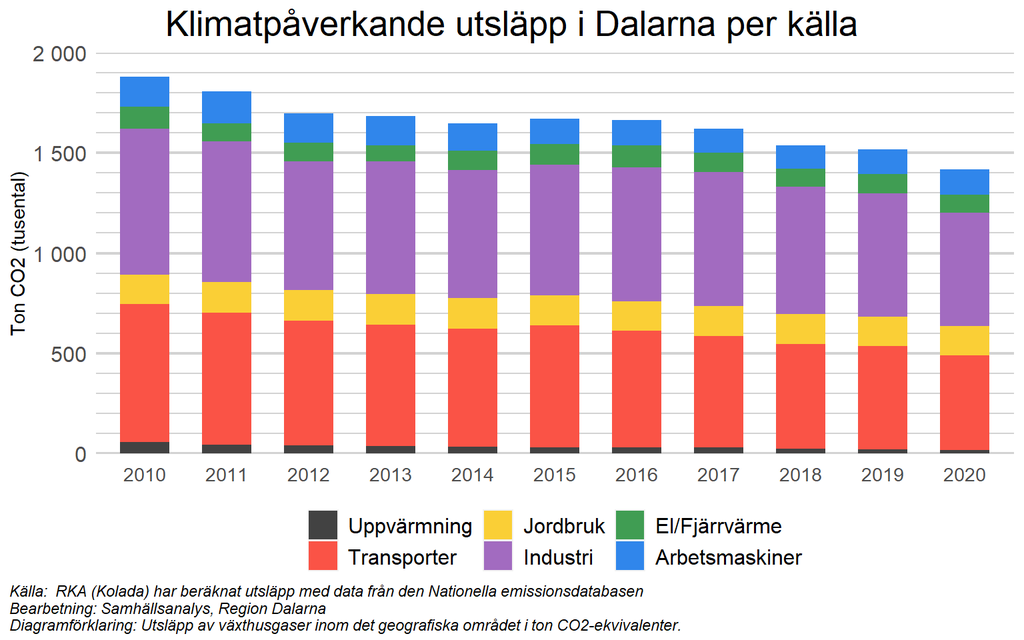

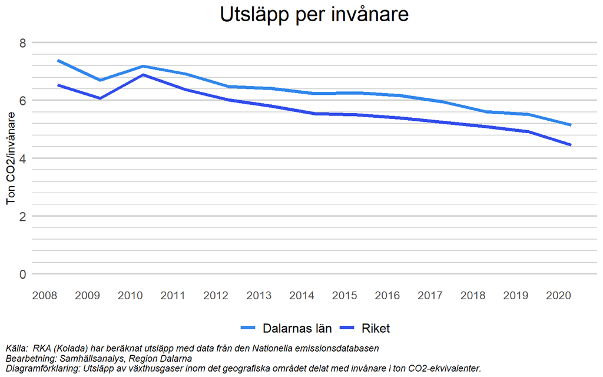

## Energiproduktion

En god tillgång till hållbar energi är avgörande för näringslivets och hela samhällets omställningsförmåga. En ökad regional produktion av förnybar energi bidrar till såväl minskade utsläpp som ökad självförsörjning och resiliens för Dalarna.

Elproduktionen i Dalarna består nästan uteslutande av vindkraft och vattenkraft. Produktionen av el från vattenkraft står för majoriteten av produktionen även om den varierar mellan olika år, bland annat beroende på om det är torrår eller våtår (se exempelvis år 2018 som var ett ovanligt torrt år). I diagrammet visas mängden el producerad av vatten- respektive vindkraft. Även om vattenkraften står för merparten så är trenden tydlig att elproduktionen från vindkraft ökar, och har mer än fördubblats sedan första mätåret 2012. År 2012 gav vindkraften ca 550 000 MVh och år 2020 gav den 1 450 000 MVh. Betydelsen av vindkraft för den totala elproduktionen har därmed också ökat från att ha utgjort ca 10 procent till att år 2020 utgöra knappt 30 procent av den totala produktionen.

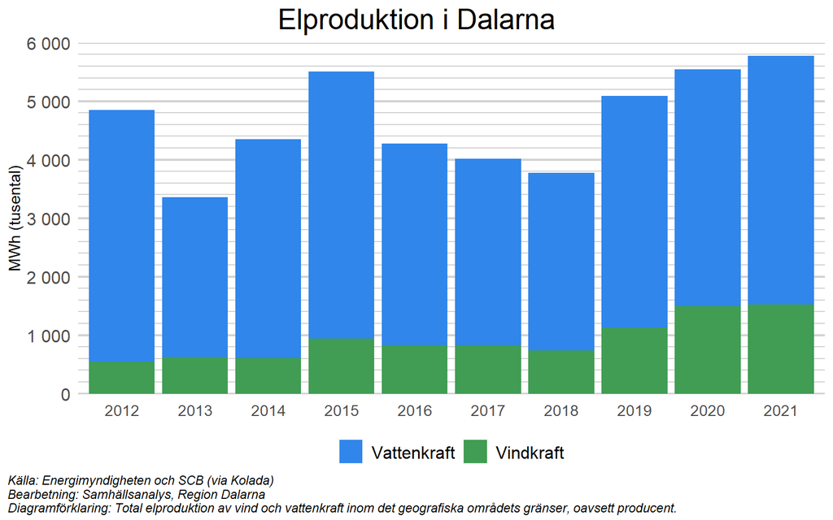

## Energieffektivitet

Ett sätt att mäta energieffektivitet är att sätta energiförbrukningen i länet i relation till de ekonomiska värden som produceras i länet. Detta skattas genom att beräkna förädlingsvärdet per ton koldioxidekvivalenter, vilket kopplar ihop utsläppen i länet med den ekonomiska aktiviteten. Att få ut ett större ekonomiskt värde av varje använd energienhet är generellt sett positivt för miljön. Forskare undersöker om det är möjligt att ha en fortsatt ökad ekonomisk tillväxt och samtidigt minska energiförbrukningen i samhället, så pass att ekonomisk aktivitet inte orsakar miljöpåverkan. Detta kallas frikoppling. Hittills visar resultaten på flera goda exempel men synliggör också konflikten mellan skyddet av naturresurser och den traditionella tillväxtmodellen som i praktiken tar naturresurser och ekosystemtjänster för givna.

Ett ökat förädlingsvärde per mängd förbrukad energi i länet kan betyda att länet har förbättrat energieffektiviteten i de fall industrier och näringar är ungefär desamma mellan mätningarna. En förklaring till en förbättrad energieffektivitet kan annars vara att näringslivets struktur har förändrats i en riktning där energikrävande industrier har lämnat regionen och mer kunskapsintensiv tjänsteproduktion har ökat (som generellt kräver mindre energi). Om energikrävande industrier har lämnat regionen och skapar utsläpp i andra delar av världen är det tyvärr inte självklart att nettoeffekten på de globala utsläppen minskat.

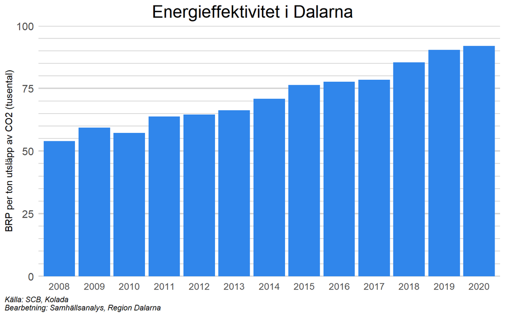

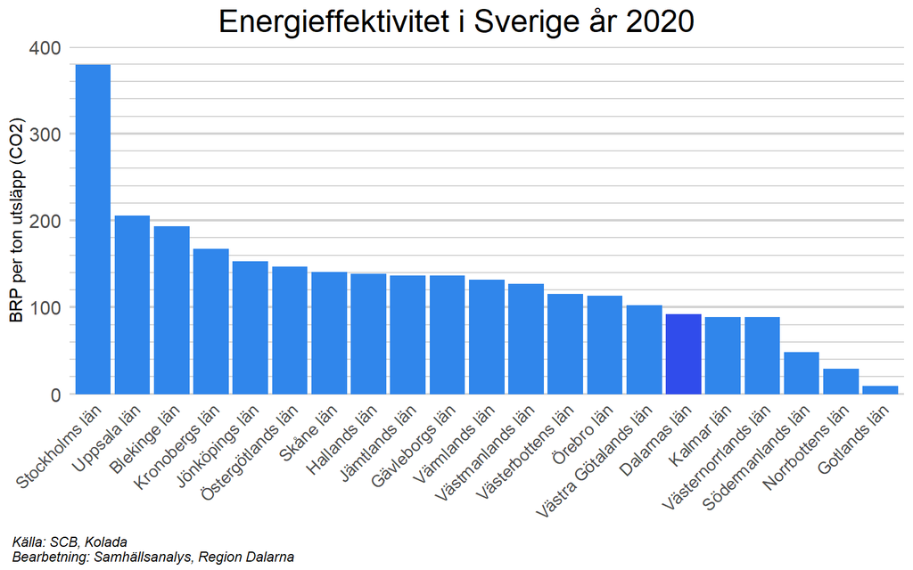

## Insamlat kommunalt avfall (kg/person)

En av prioriteringarna i Dalastrategin är att öka resurseffektiviteten i länet. Ett mått på resursförbrukning är mängden insamlat kommunalt avfall som ett mått på invånarnas resursförbrukning. I det kommunala avfallet ingår det mesta avfall som ett hushåll producerar, så som mat- och restavfall, grov- och trädgårdsavfall och farligt avfall. Även förpackningar och batterier etc. som ingår i producentansvaret ingår i beräkningen. I sammanställningen nedan visas insamlat kommunalt avfall per person och år i Dalarna från 2013 till 2021. År 2013 samlades det in 497 kg avfall per person i Dalarna, att jämföra med 478 kg per person år 2021. En lägre mängd per person signalerar en lägre resursanvändning. I en nationell jämförelse ses att Uppsalas och Stockholms län ligger bäst till med ca 400kg per person och år, medan Kalmar och Kronoberg ligger sämst till med ca 565 kg per person och år.

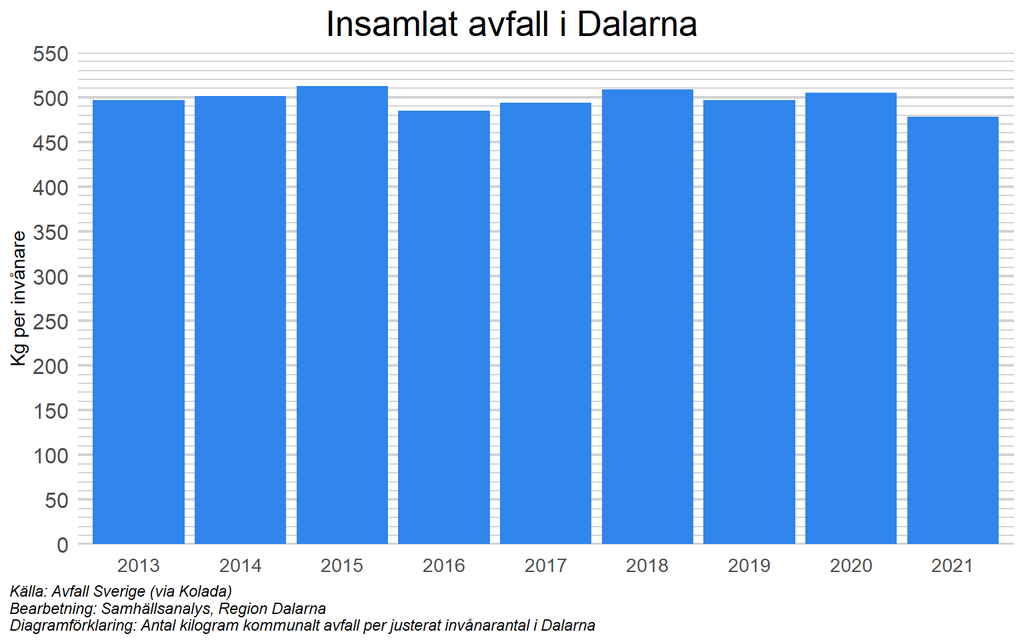

## Avfall/BRP

Ytterligare en indikator på resurseffektivitet är kopplingen mellan mängden insamlat avfall (förbrukade resurser) och den ekonomiska aktiviteten i regionen, mätt genom bruttoregionalprodukten (BRP). Indikatorn uppvisar en positiv trend av att mängden avfall minskar per producerat ekonomiskt värde över perioden från 2013 till 2021. 2013 samlades det in knappt 1 500 kg avfall för varje miljon kronor av Dalarnas BRP under samma år. 2021 hade motsvarande mängd avfall sjunkit till drygt 1 150 kg avfall. Det kan främst förklaras med att BRP har ökat under perioden.

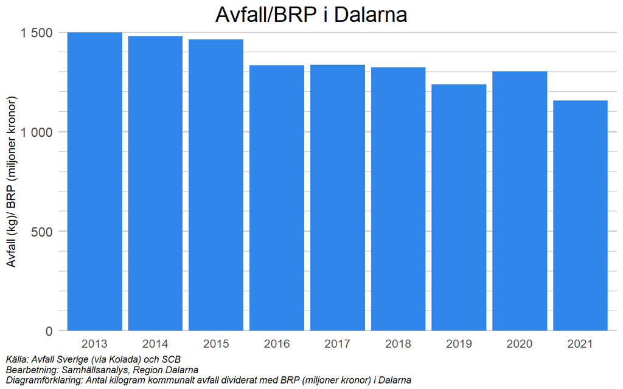

## Andel kollektivt resande

På grund av sin utsträckta och relativt glesbefolkade geografi har Dalarna en utmaning i att skapa en hållbar transportinfrastruktur. För att nå klimat- och energimålen krävs kraftfull teknisk utveckling i kombination med beteendeförändringar. Kollektivt resande spelar en central roll för utvecklandet av en klimatsmart och resurseffektiv, men också mer jämställd och jämlik, mobilitet. Kollektivtrafik är förenat med höga kostnader, samtidigt som det finns samhällsekonomiska vinster. För att klara omställningen krävs mod att ställa olika kostnader mot varandra. För att vi ska lyckas öka det kollektiva resandet behöver den traditionella kollektivtrafiken sannolikt kompletteras med nya mobilitetslösningar och tjänster, särskilt för länets mest glesbefolkade områden.

Diagrammen redovisar indikatorer för kollektivt resande i Dalarna: resor per invånare samt marknadsandel för kollektivtrafik i länet. För antal resor per invånare syns att det kollektiva resandet har legat på en stabil nivå på omkring 35 resor per person och år från 2013 fram till utbrottet av Covid-19 våren 2020. I det som förmodligen är en konsekvens av pandemin syns en nedgång i det kollektiva resandet under 2020 till 28 resor per person och år och 2021 till 25 resor. I en nationell jämförelse år 2021 framgår att det i glesbygdslänen i Sverige som mest görs 40 resor per person. Medan det görs betydligt fler i storstadsregionerna, så som Skåne med i snitt 71 resor per person och år och i Stockholm där flest resor görs, sker 230 resor per person och år.

Marknadsandelen för kollektivtrafik beräknas som andelen resor med kollektivtrafik (linjelagd buss, spårvagn, tunnelbana, pendeltåg, tåg och båt) och taxi av det totala antalet resor, dvs kollektivtrafik, taxi, bil (förare och passagerare) samt moped/MC. Även här bryts uppgången i en förmodad pandemieffekt efter ett antal år av ökande marknadsandel för kollektivtrafiken.

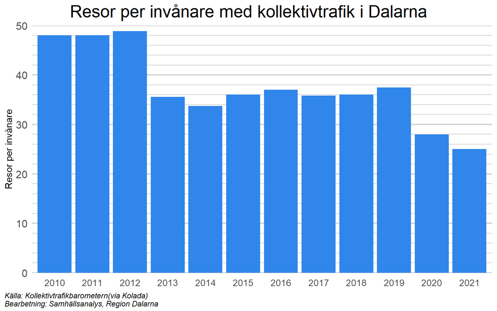

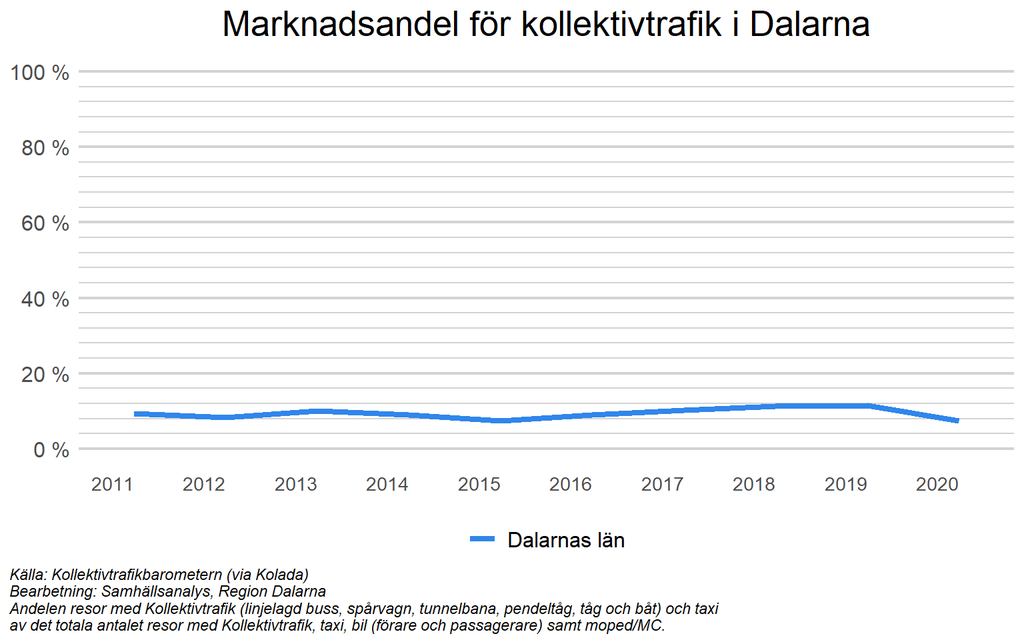

## Skattad självförsörjningsgrad av energi och livsmedel

Klimatförändringarna medför lokalt förändrade mönster för nederbörd, torka, vind, insekts- och svampangrepp på grödor och skog, höga temperaturer, med mera. Här spelar god samhällsplanering på regional och kommunal nivå en viktig roll. Ett sätt att förbättra beredskapen i Dalarna är att ha en tillräckligt omfattande lokal och hållbar livsmedelsproduktion. En ökad självförsörjningsgrad är en trygghet på flera sätt och gynnar även miljöns motståndskraft genom en ökad biologisk mångfald.

Det första diagrammet visar andelen livsmedel inom fem kategorier (fårkött, griskött, matpotatis, mjölkprodukter samt nötkött) som producerats i Dalarna i relation till den mängd livsmedel i varje kategori som konsumerats i länet. Med undantag för matpotatis år 2016 och år 2019, som vi i princip är självförsörjande på, konsumerar befolkningen i Dalarna idag betydligt mer inom samtliga kategorier jämfört med den mängd som produceras i länet.

Det andra diagrammet visar ett teroretiskt mått på självförsörjning av energi i Dalarna där den totala elproduktionen i länet visas som andel av den total elförbrukningen. Diagrammet visar en positiv trend för självförsörjningsgraden av energi, även om vi bör vara försikta med slutsatser om år 2020, då elkonsumtionen minskade på grund av pandemin. Förbättringen kan både härröras till att den regionala energiproduktionen har ökat sedan 2016, och att elkonsumtionen har minskat.

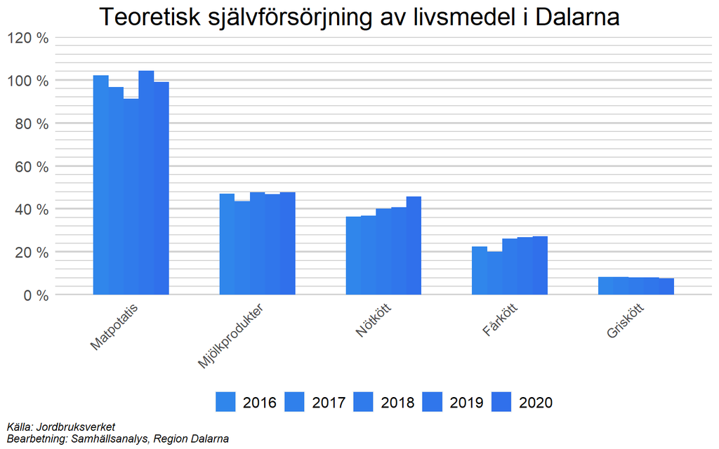

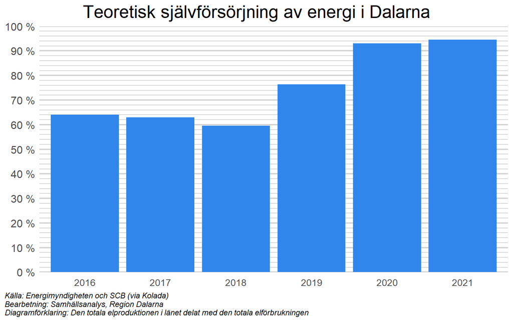

## Andel hektar formellt skyddad produktiv skogsmark

År 2018 beslutade dåvarande regering om Sveriges första nationella skogsprogram med fokus på skogsbrukets roll för en hållbar utveckling, I Dalastrategin omnämns skogsbruket som en av länets viktigare näringar. Skogsbruket påverkar och påverkas av klimatförändringarna och skötsel och brukande behöver anpassas därefter.

I diagrammen nedan redovisas utvecklingen för skyddad produktiv skogsmark i Dalarnas län mellan 2018 och 2021. Arealen skyddad skogsmark i länet är i princip densamma över tidsperioden, 116 500 hektar respektive 116 700 hektar. Procentuellt var 6,1 procent av den produktiva skogsmarken i Dalarnas län skyddad 2018 och samma siffra för 2021 var 6 procent. Det betyder att den totala arealen skogsmark har ökat något under perioden.

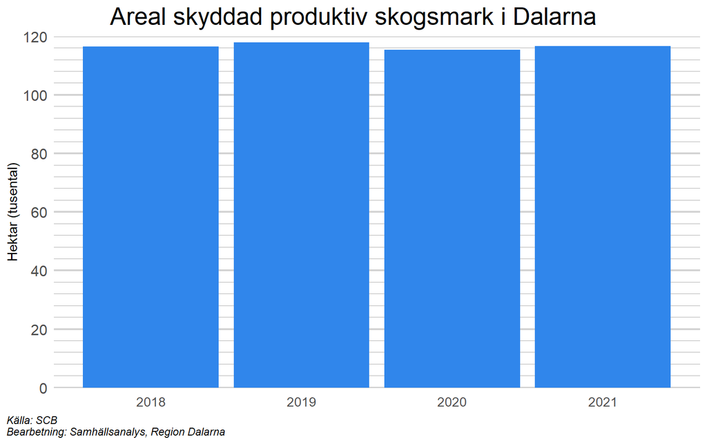

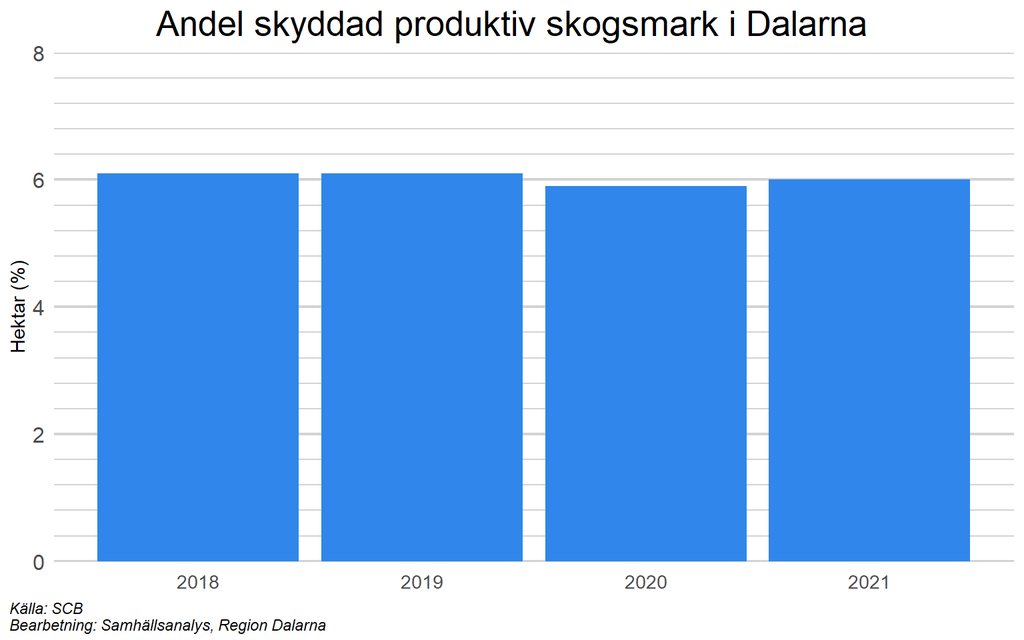

## Arealen betesmark och areal med särskilt höga biologiska värden

Biologisk mångfald och väl fungerande ekosystem är en förutsättning för allt liv på jorden. Det är också en bas för goda livsmiljöer för både Dalarnas invånare och för Dalarnas näringsliv. Den gröna infrastrukturen är ekologiskt funktionella nätverk av livsmiljöer och naturområden som utformas, brukas och förvaltas så att den biologiska mångfalden bevaras och därmed främjar de för samhället så centrala ekosystemtjänster som exempelvis vattenrening och livskraftiga jordbruksmarker etc. Samhället har allt att vinna på ett hållbart bruk av ekosystemen och att förvalta ett mångfunktionellt landskap där natur- och kulturvärden tillvaratas.

I diagrammet nedan redovisas utvecklingen för arealen betesmark i Dalarnas län mellan 2011 och 2021. Arealen har under denna period minskat från 11 908 till 10 458 hektar. Denna negativa trend går också emot den nationella trenden, där arealen betesmark har ökat något i riket som helhet. Slåtteräng är en delmängd av betesmarken som har särskilt höga biologiska värden, och därmed särskilt stor betydelse för biologisk mångfald. I Dalarna är andelen slåtteräng 1,6 procent av betesmarken.

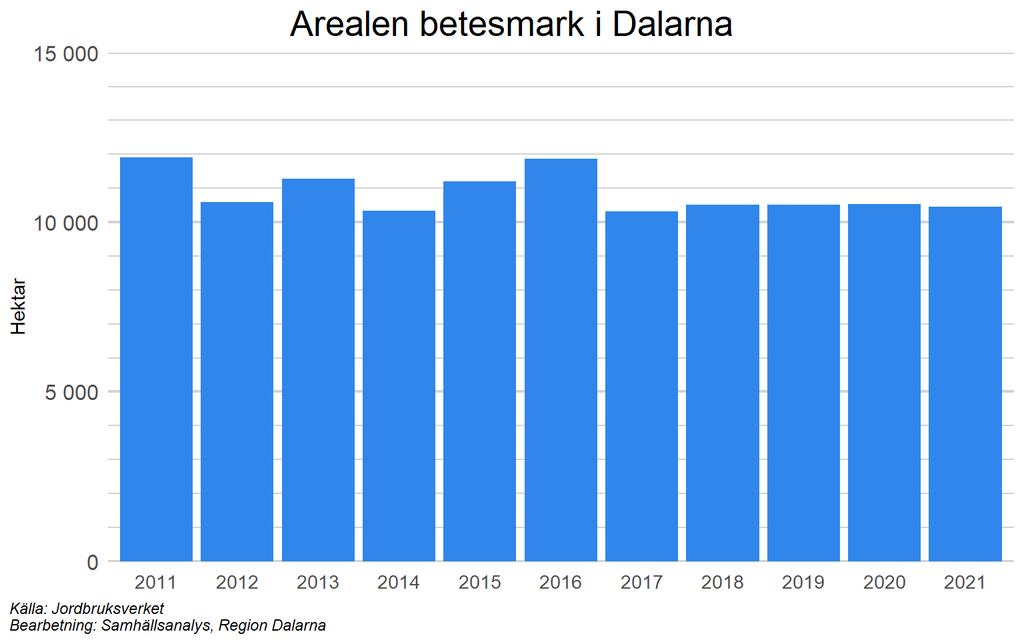

# Ett konkurrenskraftigt Dalarna

I ett konkurrenskraftigt Dalarna är näringslivet livskraftigt och bidrar till hållbar tillväxt. En väl utvecklad och hållbar infrastruktur skapar värden för näringsliv, boende och besökare. Det är ett Dalarna där allas kunskaper och kompetenser tas till vara och där individer, näringsliv, offentlig sektor och civilsamhälle utvecklas tillsammans och i samspel med omvärlden. Det är också ett nyskapande Dalarna där utmaningsdriven innovation bidrar till ett gott samhälle och hållbar tillväxt.

Den ekonomiska dimensionen av hållbarhet i det regionala utvecklingsarbetet handlar om att använda, hushålla med och förädla idéer och resurser på ett miljömässigt och socialt hållbart sätt och ta vara på möjligheterna att därigenom skapa konkurrenskraft och sysselsättning. Med ett cirkulärt system där resurser och värden kan återbrukas främjas en ekonomiskt hållbar utveckling.

## Representation i chefspositioner

Kvinnors och mäns jämställda medverkan och inflytande i näringslivet, på arbetsmarknaden och i innovationsarbete är och blir en alltmer kritisk tillväxtfaktor. Konkurrenskraften stärks när kompetenser från olika grupper oavsett ålder, kön eller bakgrund tas till vara. En viktig indikator inom detta område är representationen på arbetsplatserna, och speciellt i chefspositioner. År 2020 var det vanligare att män hade en chefsposition än kvinnor, i jämförelse med deras respektive representation bland de förvärvsarbetande. Oavsett kön är det också vanligare att inrikes födda har chefspositioner i jämförelse med utrikes födda.

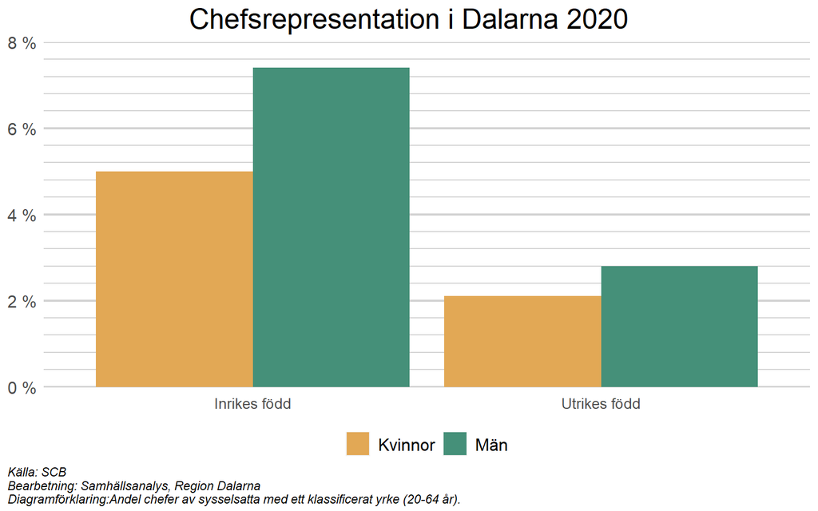

## Ginikoefficient

I Dalastrategin lyfts ekonomiska klyftor som en framtidsutmaning för länet. För att redovisa ojämlikheten i inkomstfördelningen används gini-koefficienten. Ett högt värde på koefficienten visar på större inkomstskillnader och därmed större ojämlikhet. Här redovisas ginikoefficienten beräknad genom disponibel inkomst per “konsumtionsenhet”. Med konsumtionsenhet menas att det i beräkningen av en individs tillgängliga ekonomiska resurser tas hänsyn till hur hushållet är sammansatt som individen bor i. Det betyder att beakta om personen är ensamboende eller sammanboende och om den har ansvar för minderåriga barn eller inte etc, faktorer som kan minska eller öka individens disponibla inkomst.

För Dalarnas räkning har ginikoefficienten ökat något från 2011 till 2020, vilket visar på en ökad ekonomisk ojämlikhet i länet, med en toppnotering 2019. Ginikoefficienten för länet ligger under koefficienten för riket, det vill säga i Dalarna lever befolkningen mindre ojämlikt, för samtliga år förutom 2019. 2019 avviker dock så skarpt från den generella trenden att det årets notering bör betraktas med försiktighet. Ökningen från 2011 och framåt är dock tydlig oavsett inverkan från år 2019.

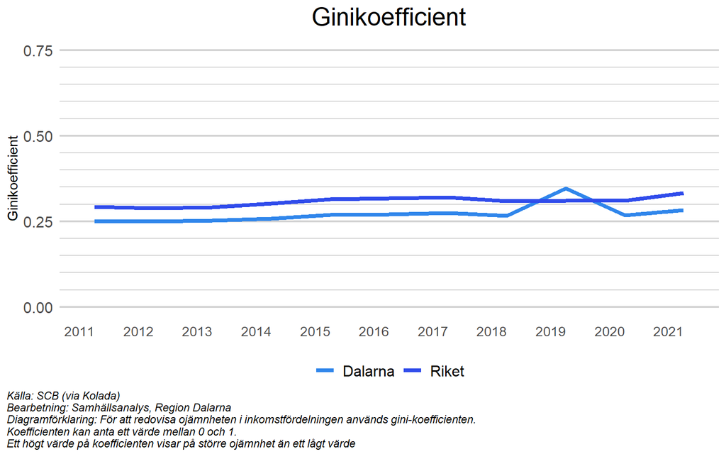

## Internationaliseringsgrad

Internationellt kunskapsutbyte och handel är viktiga faktorer för att möta samhällsutmaningar och för att ta vara på möjligheter till import, investeringar och export av varor och tjänster. I vårt län finns världsledande företag i olika storlek som deltar i globala värdekedjor, varav en del av de mindre företagen i värdekedjorna därmed spelar på den globala marknaden trots att de bara eller främst levererar till sin regionala storkund.

En indikator som används för att följa utvecklingen inom detta område är internationalisering. Internationalisering är ett komplext koncept och kan bestå av flera olika delar. I denna uppföljning används Tillväxtverkets regionala internationaliseringsindex för att illustrera internationalisering, det består av ett antal variabler om handel (export), arbetsmarknad (internationella företags betydelse för regionen) och turism (utländska gästnätter), indikator. Indexet gör det möjligt att följa hur internationaliseringen utvecklas över tid i olika regioner (län).

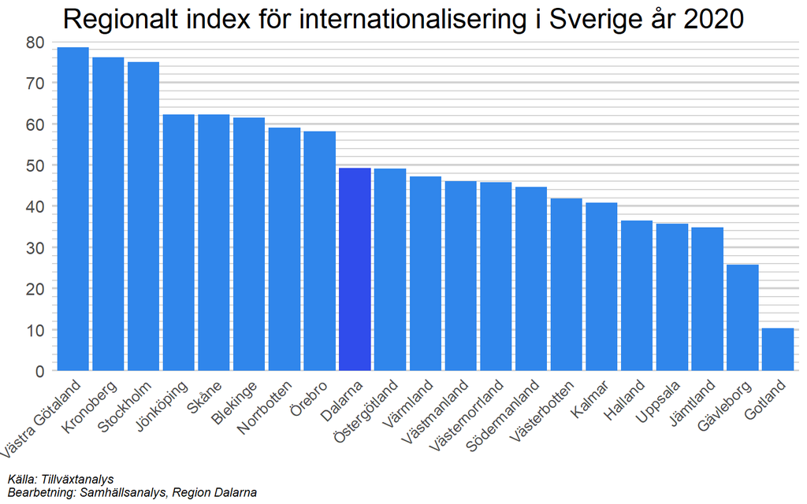

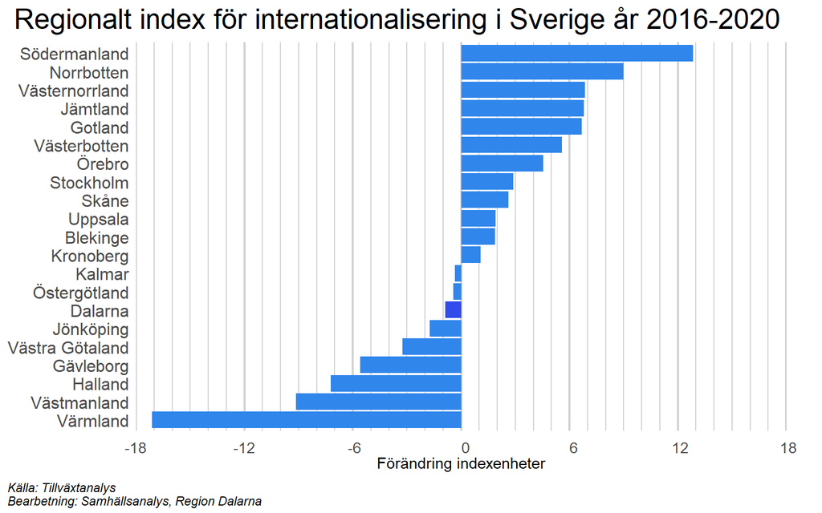

## Nyföretagande

För ekonomins och samhällets förnyelse är entreprenörskap en avgörande faktor. Dalarna behöver fler, och olika typer av entreprenörer och en av prioriteringarna i Dalastrategin är att främja entreprenörskap och företagande. Denna indikator mäter antalet nystartade företag i geografin. Antalet nystartade företag per år i Dalarna har ökat över tid där toppnoteringen nåddes 2021 med 1 748 stycken. År 2007 gjordes en större förändring i statistiken över nystartade företag vilket kan förklara den skarpa förändringen från 2006 till 2007.

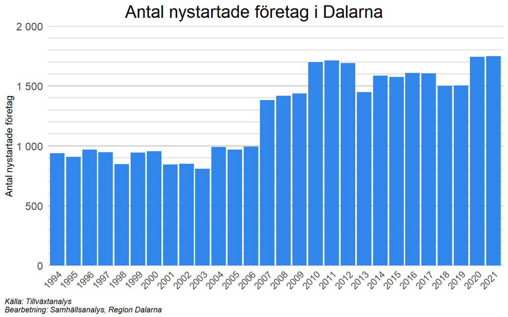

## Matchningsgrad

En förbättrad matchning mellan arbetsmarknadens behov och arbetskraftens kompetens bidrar till ett bättre nyttjande av samhällets resurser. Det handlar både om att de utbildningar som ges är efterfrågade på arbetsmarknaden och att arbetsgivare har kunskap att välja rätt kompetens. För att lyckas med detta krävs också en bättre samverkan mellan utbildningsanordnare, näringsliv, civilsamhälle och myndigheter samt en bättre dialog över kommun- och länsgränser.

I diagrammet visas matchningsgraden i form av andelen anställda som arbetar i yrken som stämmer väl överens med deras utbildning. För att detta ska gälla ska det dels finnas en stark överensstämmelse mellan utbildningens och yrkets ämnesinriktning (t.ex. teknikutbildning – teknikyrke) och dels ska utbildningsnivån vara rätt i förhållande till vad yrket kräver.

Matchningsgraden i Dalarna är något högre för kvinnor än för män, ett mönster som är återkommande över hela Sverige. För kvinnor ligger matchningsgraden 2020 på 69,6 procent. För män var motsvarande mått 68,1 procent. Den sammantagna matchningsgraden har sjunkit under perioden 2015-2020 och låg det sista året för mätningen på 68,9 procent. Nivån på matchningsgraden är snarlik över hela Sverige.

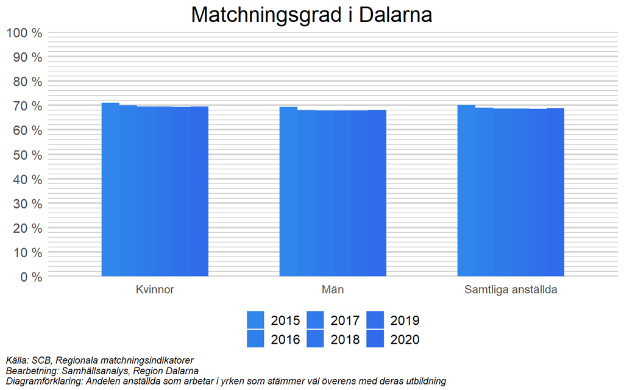

## Andel sysselsatta

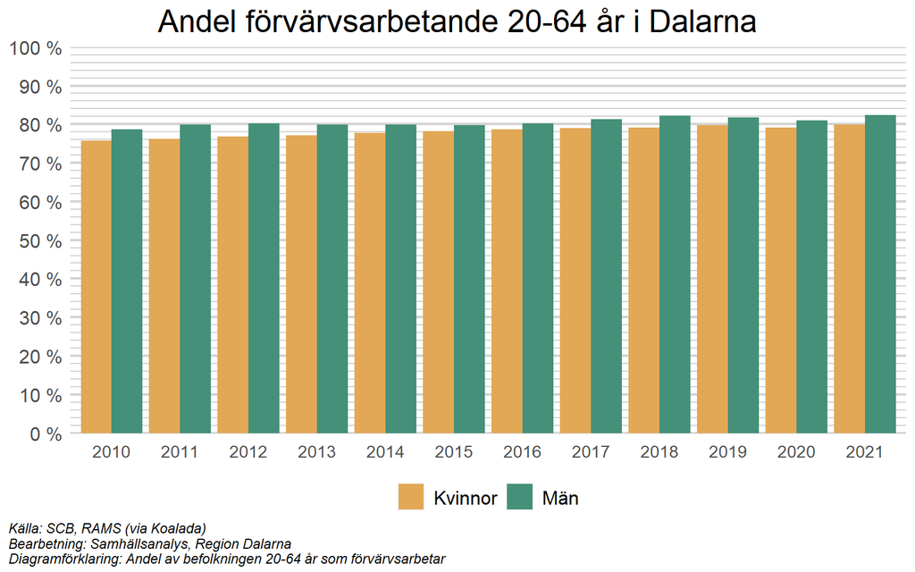

## Långtidsarbetslöshet

En annan indikator för att följa sysselsättningsutvecklingen i länet är andelen långtidsarbetslösa. Om utvecklingen för andelen förvärsarbetande kan beskrivas som positiv i rätt riktning så kan inte samma sak sägas om långtidsarbetslösheten. Som långtidsarbetslös räknas den som har varit öppet arbetslös eller i program med aktivitetsstöd i minst sex månader. År 2011 noterades 2,9 procent av länets befolkning som långtidsarbetslösa, till år 2021 hade den stigit till 3,9 procent, för att sedan sjunka till 3,4 procent år 2022. År 2021 var det relativt stor skillnad mellan kvinnor (3,7 procent) och män (4,0 procent), medan skillnaden knappt är märkbar år 2022. Riksgenomsnittet för långtidsarbetslösheten år 2022 är 3,8 procent, och Dalarna ligger därmed under riksgenomsnittet. En generell orsak till långtidsarbetslöshet är strukturarbetslöshet som innebär att de arbetssökande saknar rätt kompetens för de arbeten som det finns efterfrågan på.

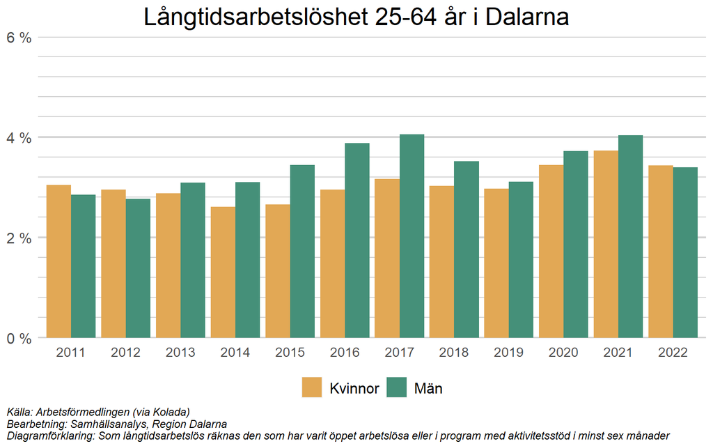

## Andel unga som inom fyra år fullföljer gymnasieutbildning

Kunskap ger människor möjlighet att växa och påverka sin livssituation. Tillgång till bildning, kunskap och kompetens är avgörande för såväl utvecklingen av samhället, som god välfärd och tillväxt i näringslivet. När arbetsgivare inte hittar rätt kompetens hämmas den ekonomiska utvecklingen. Samtidigt försvagas den sociala hållbarheten när människor ställs utanför arbetsmarknaden. Befolkningens låga utbildningsnivåer är en utmaning i stora delar av Dalarna. Ambitionen i Dalastrategin är att fler ska klara en gymnasieexamen för att därmed få bättre förutsättningar att etablera sig på arbetsmarknaden.

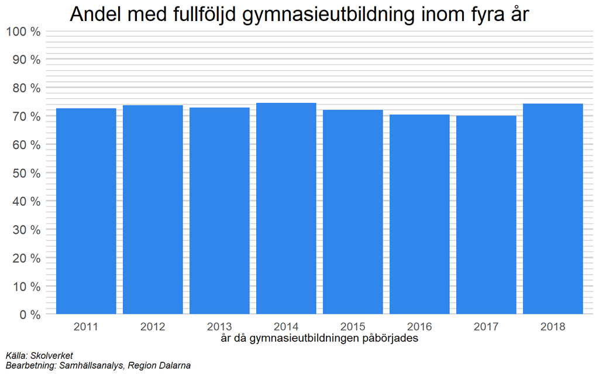

## Andel högskoleutbildade i befolkningen

Med ett alltmer kunskapsintensivt samhälle och en arbetsmarknad som ställer högre krav på kompetens ökar också behovet av eftergymnasialt utbildade. I Dalastrategin poängteras betydelsen av en stark regional högskola med närvaro i hela länet. Även andra utbildningsformer såsom folkhögskolor, yrkesvux och yrkeshögskolor bidrar till att stärka kompetensförsörjningen i länet i form av såväl bredd som spets. Denna indikator mäter andelen invånare med eftergymnasial utbildning i åldersspannet 25 till 64 år. Med eftergymnasial utbildning avses både eftergymnasial utbildning kortare än tre år, längre än tre år och forskarutbildning.

Andelen högskoleutbildade i länet ökar över tid. Från 31,2 procent år 2013 till 34,9 procent 2021. Skillnaden mellan kvinnors och mäns utbildningsnivå är tydlig, år 2021 hade 42,6 procent av kvinnorna i Dalarna någon form av eftergymnasial utbildning, medan motsvarande siffra för männen i Dalarna var avsevärt lägre, 27,5 procent. Det är även tydligt att skillnaden har ökat över tidsperioden.

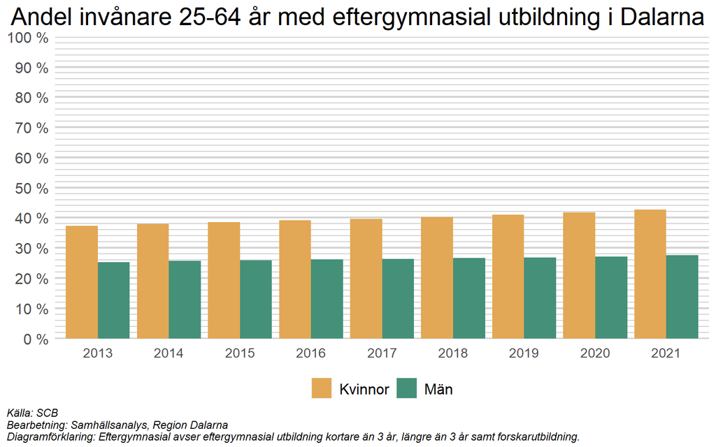

## Etableringstid för nyanlända

Invandring är en del av lösningen för att möta en ökad efterfrågan på arbetskraft och rätt kompetens. Dalarna har haft en relativt stor inflyttning av utomeuropeiskt födda under senare år. Många invandrade är i arbetsför ålder och blir därför ett viktigt tillskott till arbetskraften. Denna indikator är ett mått på i vilken takt och utsträckning som nyanlända etablerar sig på arbetsmarknaden i Dalarna. Med etablering menas att personen är förvärvsarbetande helt utan stöd från a-kassa eller arbetsmarknadsåtgärd, eller dylikt.

Diagrammet visar tydligt hur andelen etablerade på arbetsmarknaden i arbetsför ålder ökar efter vistelsetid i landet. För det senaste året i period, 2021, hade drygt 39 procent av invandrade med vistelsetid under ett år etablerat sig på arbetsmarknaden. Andelen etablerade på arbetsmarknaden ökar sedan alltmer efter vistelsetid och för samma år var det ca 72 procent i gruppen som vistats i Sverige i tio år eller mer som var etablerade på arbetsmarknaden.

Ytterligare en positiv trend är att det över tid verkar gå snabbare för nyanlända att etablera sig på arbetsmarknaden. Från 2010 till 2021 har andelen etablerade på arbetsmarknaden i gruppen med vistelsetid under ett år, ökat från ca 16 procent till drygt 39 procent, vilket är mer än en fördubbling. Det finns dessvärre tydliga skillnader mellan mäns och kvinnors förutsättningar att etablera sig de första åren. En betydligt högre andel män har lyckats etablera sig på arbetsmarknaden inom nio år i jämförelse med andelen kvinnor. Efter minst 10 år i landet är dock kvinnorna i princip ikapp männen. Cirka 72 procent i respektive grupp är etablerad, och det skiljer endast 0,4 procentenheter mellan grupperna.

I en jämförelse med övriga län av andelen etablerade efter minst 10 år i Sverige, återfinns Dalarna i mittensegmentet. Hallands län har den högsta andelen etablerade med 78 procent, och i Skåne är andelen etablerade efter minst 10 år i landet lägst, med ca 68 procent.

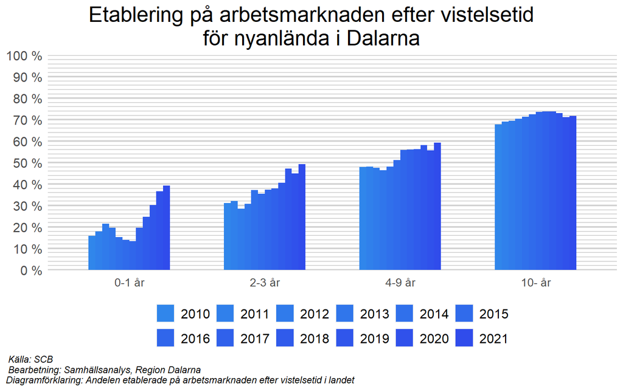

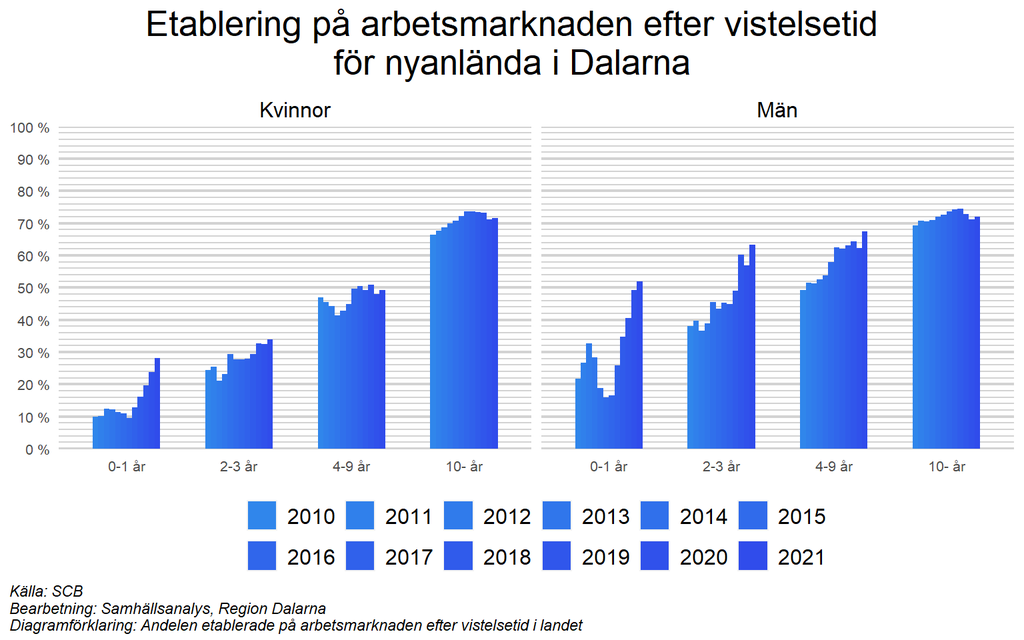

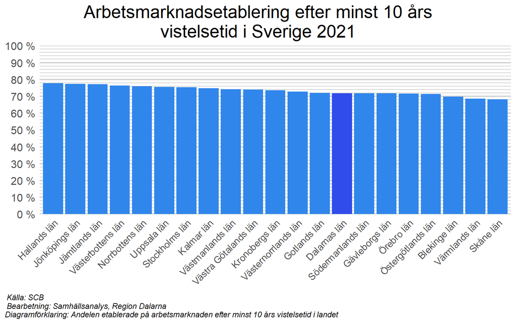

## Investeringar i FoU

För att lösa dagens och morgondagens samhällsutmaningar och för att skapa utveckling och konkurrenskraft krävs ökad innovationskraft. Individers, företags, organisationers och offentlig sektors innovationsförmåga påverkar platsers utvecklingskraft och möjligheter till omställning. Denna indikator mäter investeringar i forskning och utveckling i länet. Det bör dock påpekas att innovation och forskning är ett synnerligen svårt område att mäta och att denna indikator främst ger en övergripande bild av vilka resurser som investeras i länet.

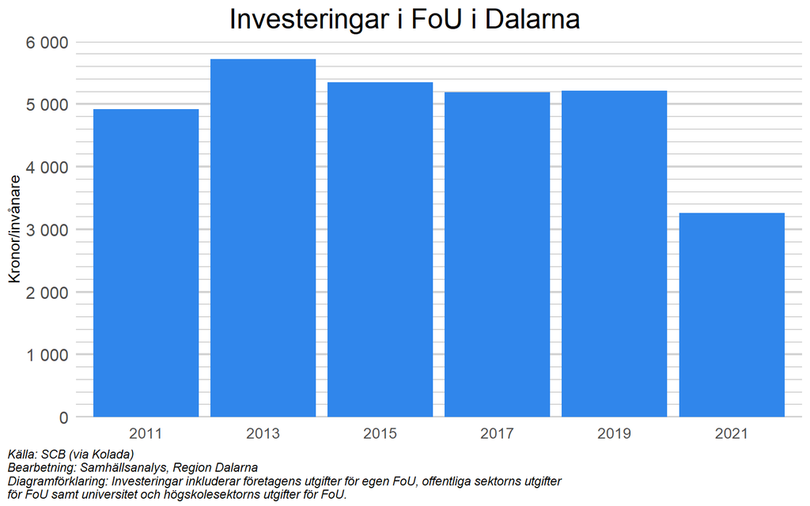

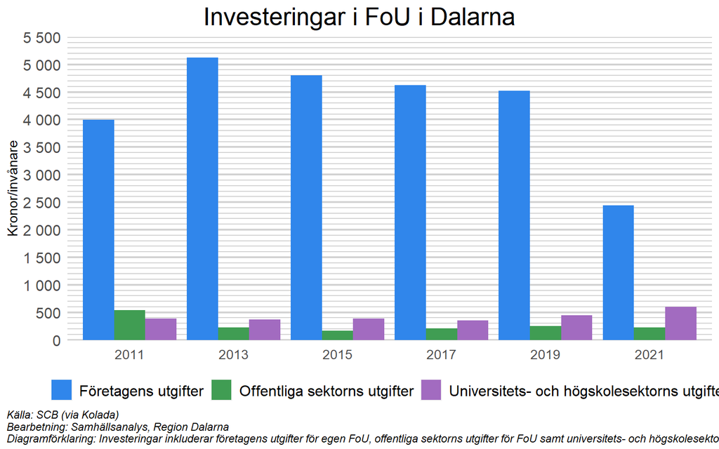

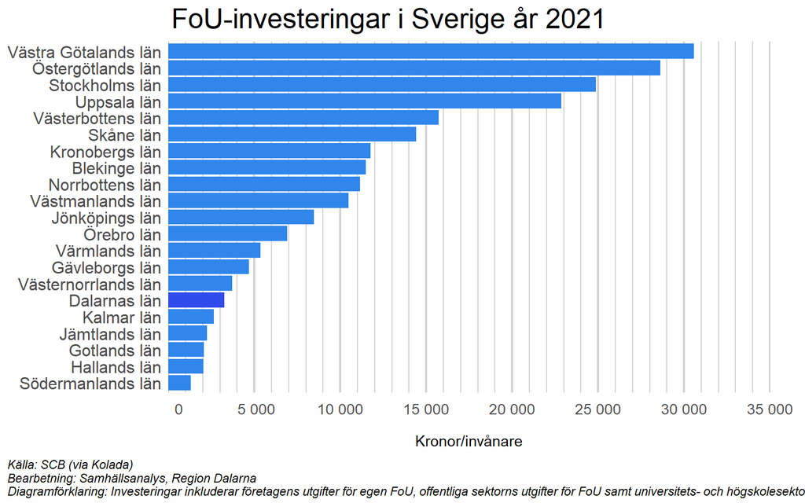

# Ett sammanhållet Dalarna

I ett sammanhållet Dalarna finns goda livsmiljöer som skapar en känsla av närhet. Det är ett Dalarna fyllt av engagemang, där människor upplever delaktighet och tillsammans bidrar till en hållbar utveckling. Det är ett inkluderande, jämställt, och jämlikt Dalarna där människor mår bra och där alla ges möjlighet att utvecklas.

Den sociala dimensionen av hållbarhet i det regionala utvecklingsarbetet handlar om att alla människor, utifrån sina behov och förutsättningar, ges likvärdiga möjligheter att delta i samhällsutvecklingen. Ju fler som känner sig delaktiga, desto mer utveckling kan åstadkommas.

## Trångboddhet

Goda livsmiljöer som upplevs som trygga och inkluderande är en förutsättning för att människor ska må bra. Olika platser i Dalarna har olika utmaningar och möjligheter att möta dessa behov, bland annat beroende på om det är platser med växande eller krympande befolkningsunderlag. Indikatorn trångboddhet relaterar bland annat till prioriteringen i Dalastrategin om diversifierade boendeformer som i sin tur ska motverka segregation och polarisering.

Antalet trångbodda i Dalarna har ökat under perioden från 2012 till 2021. I början på perioden räknades cirka 8 800 individer i Dalarna som trångbodda enligt norm 2. Nio år senare har denna siffra ökat till 14 500 personer. Norm 2 innebär att de boende räknas som trångbodda om de bor fler personer än två per rum i alla rum som inte räknas som kök eller vardagsrum.

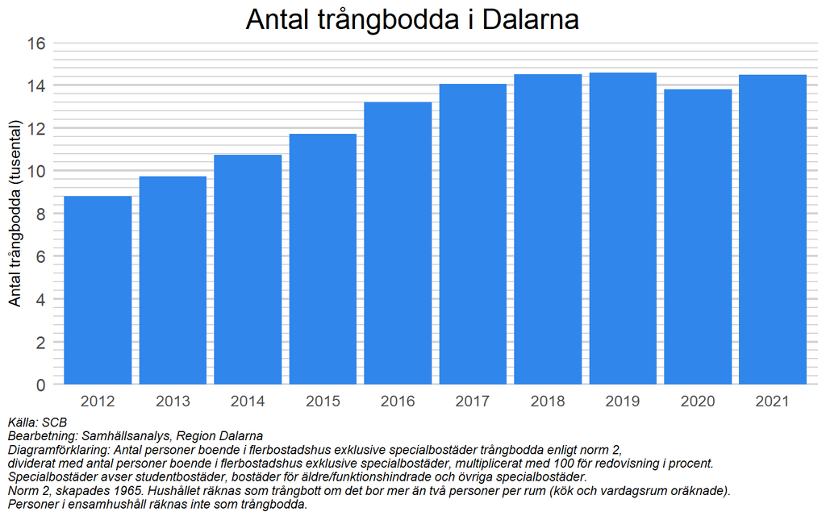